# Modeling (Logistic Regression)

Sebastian Deri

[return to overview page]

As Gelman & Hill (2006, p. 79) note “logistic regression is the standard way to model binary outcomes.” So let’s start our predictive modeling here. Our focus throughout will be on assessing the performance of the logistic regression models we build – more so than interpreting coefficients, which is often the focus in a great deal of social science research (where the emphasis is on explanation and thus the variables which “explain” some outcome).

# Packages

Again, I will start by loading relevant packages.

```r
# before knitting: message = FALSE, warning = FALSE
library(tidyverse) # cleaning and visualization
library(ggthemes) # visualization
library(caret) # modeling
library(broom) # needed for ggcoef function
library(GGally) # has ggcoef function
library(AppliedPredictiveModeling)
library(pROC) # ROC curve
```

# Load Data

Next, I will load the pre-processed data, which we created earlier (see Data Cleaning & Pre-Processing). This dataset has a row for each of 5,004 statements, a column indicating whether that particular statement was a truth or a lie, and 90 possible predictor variables for each statement, which comes from the textual features we extracted earlier.

```r
# load pre-processed df's
load("stats_proc.Rda")
```

# EXAMPLE (Single Predictive Logistic Regression Model)

As usual, let’s begin with an example. Here we will simply train and test one single logistic regression model.

## Split Sample Into Training and Testing Sets

Our first step will be to split the entire dataset into two parts – our training data set, on which the model will be build, and our testing data set, on which the performance of our model will be evaluated. Although many possible splits would be acceptable (e.g. 75-25, 90-10), we are going to conduct an exact 50-50 split, randomly allocating one half of the statements to the training set, and the other half to the testing set. The createDataPartition function in the caret packages makes this easy (Kuhn, 2008).

```r
# set seed, so that statistics don't keep changing for every analysis
set.seed(2019)

# partition data in 50-50 lgocv split (create index for test set)
index_train_ex <-
  createDataPartition(y = stats_proc$stat_id,
                      p = 0.50,
                      times = 1,
                      list = FALSE)

# actually create data frame with training set (predictors and outcome together)
train_set_ex <- stats_proc[index_train_ex, ]

# actualy create data frame with test set (predictors and outcome together)
test_set_ex <- stats_proc[-index_train_ex, ]
```

## Build Model (on Training Set)

Now that the data are split, we can fit a logistic regression model to the training data. Again, the caret package makes this easy with its “train” function (Kuhn, 2008), which allows us to select from over 238 different model type (Kuhn, 2019; see: [Chapter 7](https://topepo.github.io/caret/train-models-by-tag.html), including of course the logistic regression model from the family of general lineal models. A single logistic regression model is fitted below.

```r
# set seed, so that statistics don't keep changing for every analysis
# (applies for models which might have random parameters)
set.seed(2019)

# start timer
start_time <- Sys.time()

# use caret "train" function to train logistic regression model
model_ex <-
  train(form = grd_truth ~ . - stat_id,
        data = train_set_ex,
        method = "glm",
        family = "binomial")

# end timer
total_time <- Sys.time() - start_time
```

## Coefficients

In logistic regression, we model the log odds of a binary event (i.e. log(p/(1-p))) as a linear combination of our chosen predictor variables (with some arithmetic, we can then convert things so we are estimating raw probabilites, from 0 to 1) (Gelman & Hill (2006), Chapter 5; Logistic regression 2019). Normally, our focus would be on interpreting the coefficients of the individual predictor variables in this resulting model – for insight into what sorts of factors explains the occurrence of our binary outcome. These are shown below (with 95% CI’s) in decreasing order.

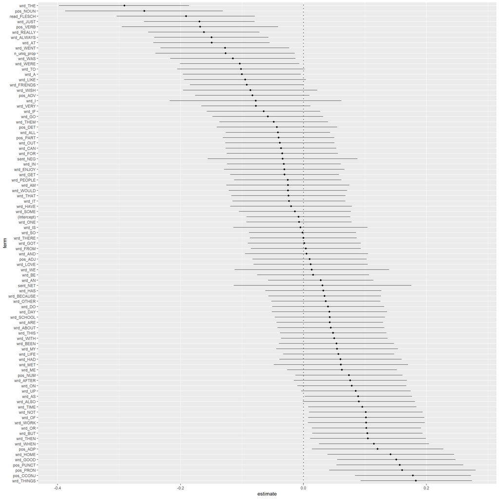

```r
# use ggcoef from GGally, that allows for nice plotting of coeffs
ggcoef(model_ex$finalModel,
       sort = "decending")
```

## Evaluate Model (on Testing Set)

```r
# make predictions
preds_ex <-
  predict(object = model_ex,
          newdata = test_set_ex,
          type = "raw")

# record model performance
conf_ex <-
  confusionMatrix(data = preds_ex,
                  reference = test_set_ex$grd_truth,
                  positive = "truth")

# print confusion matrix
conf_ex
```

```
## Confusion Matrix and Statistics
##
##           Reference
## Prediction lie truth
##      lie   791   523
##      truth 459   727
##
##                Accuracy : 0.6072
##                  95% CI : (0.5877, 0.6264)
##     No Information Rate : 0.5
##     P-Value [Acc > NIR] : < 2e-16
##
##                   Kappa : 0.2144
##  Mcnemar's Test P-Value : 0.04439
##
##             Sensitivity : 0.5816
##             Specificity : 0.6328
##          Pos Pred Value : 0.6130
##          Neg Pred Value : 0.6020
##              Prevalence : 0.5000
##          Detection Rate : 0.2908
##    Detection Prevalence : 0.4744
##       Balanced Accuracy : 0.6072
##
##        'Positive' Class : truth
##
```

# FULL (Predictive Logistic Regression Models)

Our full analysis will almost exactly replicate what we did in our example case above, except we will replicate the procedure ten times. Thus, we will build 10 different logistic regression models using 10 different training sets and evaluate them on their 10 different (corresponding) test sets.

## Run 10 models

Below is the code that runs through this modeling process 10 different times and saves the result from each round.

```r
# # -----------------------------------------------------------------------------
# STEP 0: set seed, so that statistics don't keep changing for every analysis
set.seed(2019)

# # -----------------------------------------------------------------------------
# STEP 1: decide how many times to run the model
rounds <- 10

# -----------------------------------------------------------------------------
# STEP 2: set up object to store results
# part a: create names of results to store
result_cols <- c("model_type", "round", "accuracy", "accuracy_LL", "accuracy_UL",
                 "sensitivity", "specificity", "precision", "npv", "n")

# part b: create matrix
results <-
  matrix(nrow = rounds,
         ncol = length(result_cols))

# part c: actually name columns in results marix
colnames(results) <- result_cols

# part d: convert to df (so multiple variables of different types can be stored)
results <- data.frame(results)

# -----------------------------------------------------------------------------
# STEP 2: start timer
start_time <- Sys.time()

# -----------------------------------------------------------------------------
# STEP 3: create rounds number of models, and store results each time

for (i in 1:rounds){

  # part a: partition data in 50-50 lgocv split (create index for test set)
  index_train <-
    createDataPartition(y = stats_proc$stat_id,
                        p = 0.50,
                        times = 1,
                        list = FALSE)

  # part b: create testing and training data sets
  train_set <- stats_proc[index_train, ]
  test_set <- stats_proc[-index_train, ]


  # part c: use caret "train" function to train logistic regression model
  model <-
    train(form = grd_truth ~ . - stat_id,
          data = train_set,
          method = "glm",
          family = "binomial")

  # part d: make predictions
  preds <-
    predict(object = model,
            newdata = test_set,
            type = "raw")

  # part e: store model performance
  conf_m <-
    confusionMatrix(data = preds,
                    reference = test_set$grd_truth,
                    positive = "truth")

  # part f: store model results
  # model type
  results[i, 1] <- "logistic"
  # round
  results[i, 2] <- i
  # accuracy
  results[i, 3] <- conf_m$overall[1]
  # accuracy LL
  results[i, 4] <- conf_m$overall[3]
  # accuracy UL
  results[i, 5] <- conf_m$overall[4]
  # sensitivity
  results[i, 6] <- conf_m$byClass[1]
  # specificity
  results[i, 7] <- conf_m$byClass[2]
  # precision
  results[i, 8] <- conf_m$byClass[3]
  # negative predictive value
  results[i, 9] <- conf_m$byClass[4]
  # sample size (of test set)
  results[i, 10] <- sum(conf_m$table)

  # part g: print round and total elapsed time so far
  cumul_time <- difftime(Sys.time(), start_time, units = "mins")
  print(paste("round #", i, ": cumulative time ", round(cumul_time, 2), " mins",
              sep = ""))
  print("--------------------------------------")

}
```

```
## [1] "round #1: cumulative time 0.13 mins"
## [1] "--------------------------------------"
## [1] "round #2: cumulative time 0.25 mins"
## [1] "--------------------------------------"
## [1] "round #3: cumulative time 0.36 mins"
## [1] "--------------------------------------"
## [1] "round #4: cumulative time 0.48 mins"
## [1] "--------------------------------------"
## [1] "round #5: cumulative time 0.59 mins"
## [1] "--------------------------------------"
## [1] "round #6: cumulative time 0.71 mins"
## [1] "--------------------------------------"
## [1] "round #7: cumulative time 0.83 mins"
## [1] "--------------------------------------"
## [1] "round #8: cumulative time 0.95 mins"
## [1] "--------------------------------------"
## [1] "round #9: cumulative time 1.08 mins"
## [1] "--------------------------------------"
## [1] "round #10: cumulative time 1.19 mins"
## [1] "--------------------------------------"
```

## View Results (Tabular)

```r
results
```

| model_type | round | accuracy | accuracy_LL | accuracy_UL | sensitivity | specificity | precision | npv | n |
| --- | --- | --- | --- | --- | --- | --- | --- | --- | --- |
| logistic | 1 | 0.6072 | 0.5877396 | 0.6264089 | 0.5816 | 0.6328 | 0.6129848 | 0.6019787 | 2500 |
| logistic | 2 | 0.6060 | 0.5865308 | 0.6252205 | 0.6224 | 0.5896 | 0.6026336 | 0.6095947 | 2500 |
| logistic | 3 | 0.6072 | 0.5877396 | 0.6264089 | 0.6176 | 0.5968 | 0.6050157 | 0.6094771 | 2500 |
| logistic | 4 | 0.6048 | 0.5853221 | 0.6240321 | 0.5984 | 0.6112 | 0.6061588 | 0.6034755 | 2500 |
| logistic | 5 | 0.5976 | 0.5780722 | 0.6168988 | 0.5904 | 0.6048 | 0.5990260 | 0.5962145 | 2500 |
| logistic | 6 | 0.6152 | 0.5958017 | 0.6343280 | 0.5992 | 0.6312 | 0.6190083 | 0.6116279 | 2500 |
| logistic | 7 | 0.6104 | 0.5909638 | 0.6295772 | 0.6032 | 0.6176 | 0.6120130 | 0.6088328 | 2500 |
| logistic | 8 | 0.6072 | 0.5877396 | 0.6264089 | 0.5944 | 0.6200 | 0.6100164 | 0.6045242 | 2500 |
| logistic | 9 | 0.5944 | 0.5748515 | 0.6137271 | 0.6024 | 0.5864 | 0.5929134 | 0.5959350 | 2500 |
| logistic | 10 | 0.5968 | 0.5772670 | 0.6161059 | 0.5840 | 0.6096 | 0.5993432 | 0.5943838 | 2500 |

## View Results (Graphically)

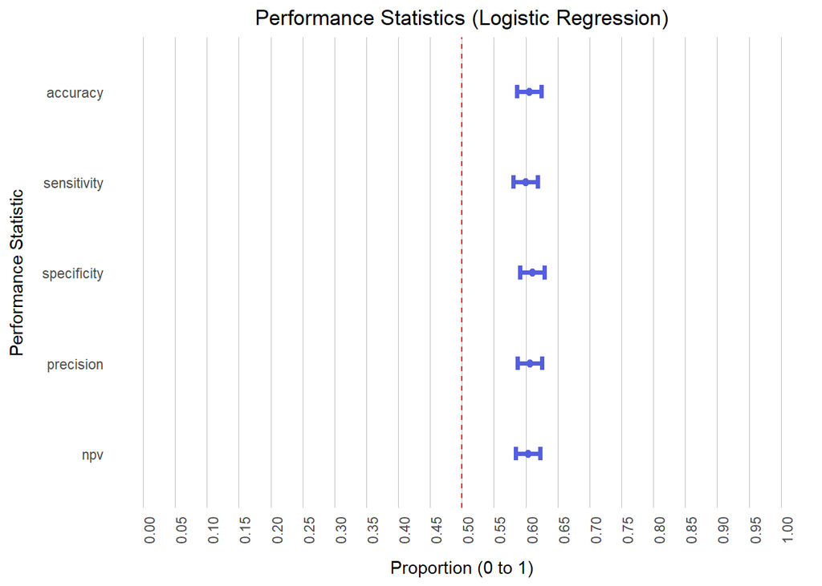

```r
# calculate average sample size
mean_n <- mean(results$n)

# create df to use for visualization
results_viz <-
  results %>%
  group_by(model_type) %>%
  summarize(accuracy = mean(accuracy),
            sensitivity = mean(sensitivity),
            specificity = mean(specificity),
            precision = mean(precision),
            npv = mean(npv)) %>%
  select(-model_type) %>%
  gather(key = "perf_stat",
         value = "value") %>%
  mutate(value = as.numeric(value))

# actual visualization
ggplot(data = results_viz,
  aes(x = perf_stat,
           y = value)) +
geom_point(size = 2,
           color = "#545EDF") +
geom_errorbar(aes(ymin = (value - 1.96*sqrt(value*(1-value)/mean_n)),
                   ymax = (value + 1.96*sqrt(value*(1-value)/mean_n))),
              color = "#545EDF",
              width = 0.15,
              size = 1.25) +
geom_hline(yintercept = 0.5,
           linetype = "dashed",
           size = 0.5,
           color = "red") +
scale_y_continuous(breaks = seq(from = 0, to = 1, by = 0.05),
                   limits = c(0, 1)) +
scale_x_discrete(limits = rev(c("accuracy", "sensitivity", "specificity",
                            "precision", "npv"))) +
coord_flip() +
theme(panel.grid.major.x = element_line(color = "grey",
                                        size = 0.25),
      panel.grid.minor.x = element_blank(),
      panel.grid.major.y = element_blank(),
      panel.background = element_blank(),
      axis.ticks = element_blank(),
      plot.title = element_text(hjust = 0.5),
      axis.title.y = element_text(margin =
                                    margin(t = 0, r = 10, b = 0, l = 0)),
      axis.title.x = element_text(margin =
                                    margin(t = 10, r = 00, b = 0, l = 0)),
      axis.text.x = element_text(angle = 90)) +
labs(title = "Performance Statistics (Logistic Regression)",
     x = "Performance Statistic",
     y = "Proportion (0 to 1)")
```

# Save Results

```r
# rename results df, to be particular to this model type (for disambiguation later)
results_log <- results

# clear results variable
rm(results)

# save results in Rda file
save(results_log,
     file = "results_log.Rda")
```